# TP6 - Classification Ascendante Hiérarchique

Simon Desdevises

2025-10-02

# Lecture des données

On retrouve les informations énergétiques de différents fromages.

Ce sont les suivants :

- `"calories"` : Calories
- `"sodium"` : Sodium
- `"calcium"` : Calcium
- `"lipides"` : Lipides
- `"retinol"` : Retinol
- `"folates"` : Folates
- `"proteines"` : Protéines
- `"cholesterol"` : Cholestérol
- `"magnesium"` : Magnésium

# ACP

## Valeurs propres et variance expliquée

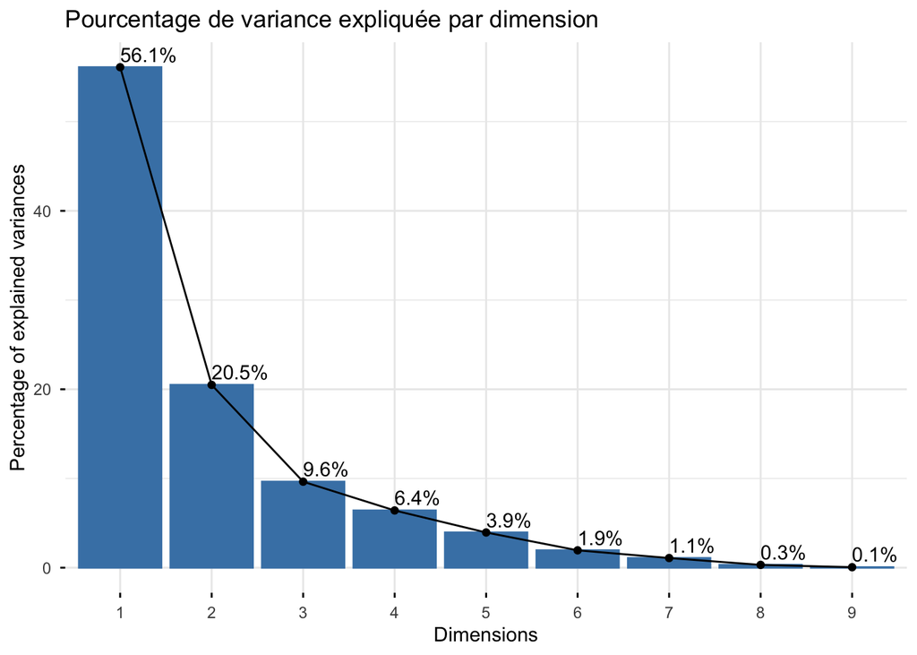

Les 2 premiers axes expliquent 76.6% de la variance. C’est donc un bon indicateur de la qualité de l’ACP.

## Premier plan factoriel

### Graphique des individus

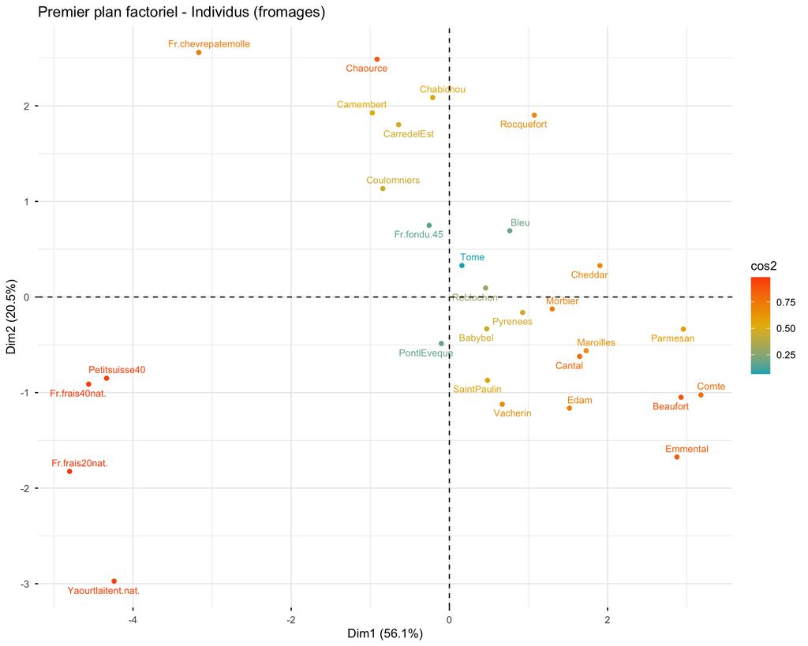

### Graphique des variables

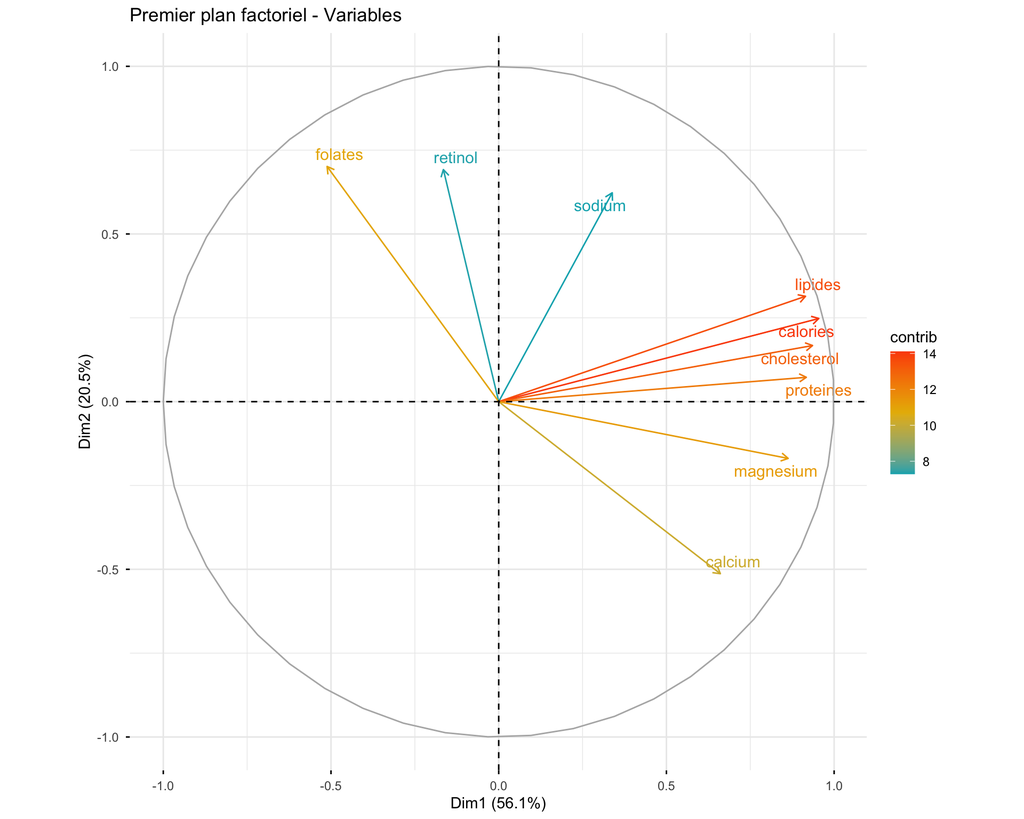

### Biplot (individus et variables)

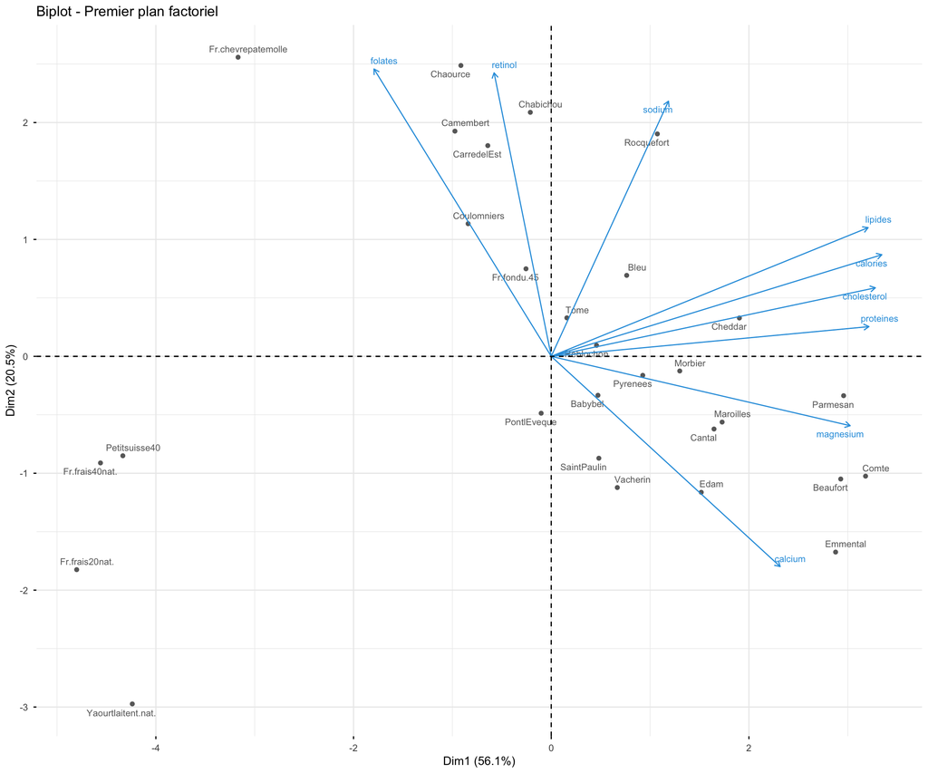

# Groupe d’individus

On observe déjà plusieurs groupes distincts. :

- Les fromages industriels comme `Petitsuisse40` ou `Fr.frais20nat`. Ils sont regroupé tout à gauche du graphique des individus.
- Les autres fromages sont plutôt regroupés il faudra donc poursuivre l’analyse.

# Realisation de la CAH

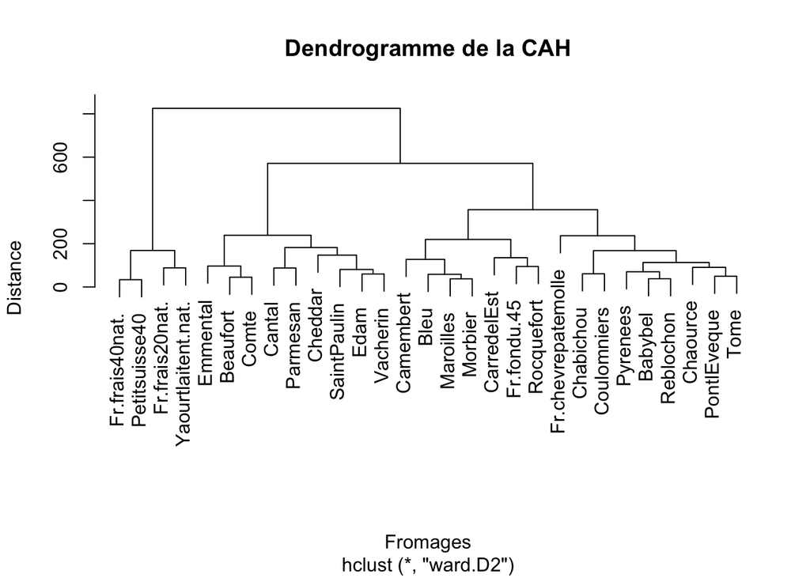

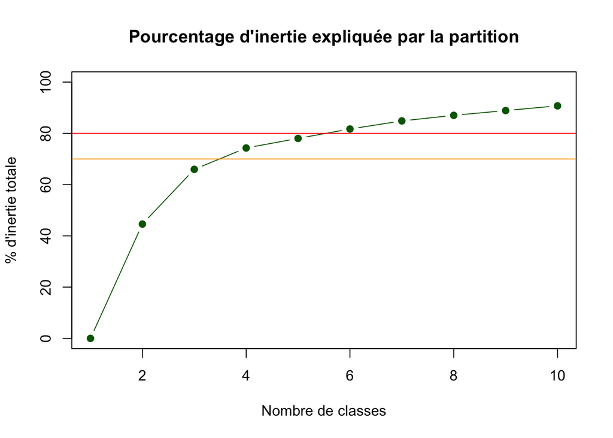

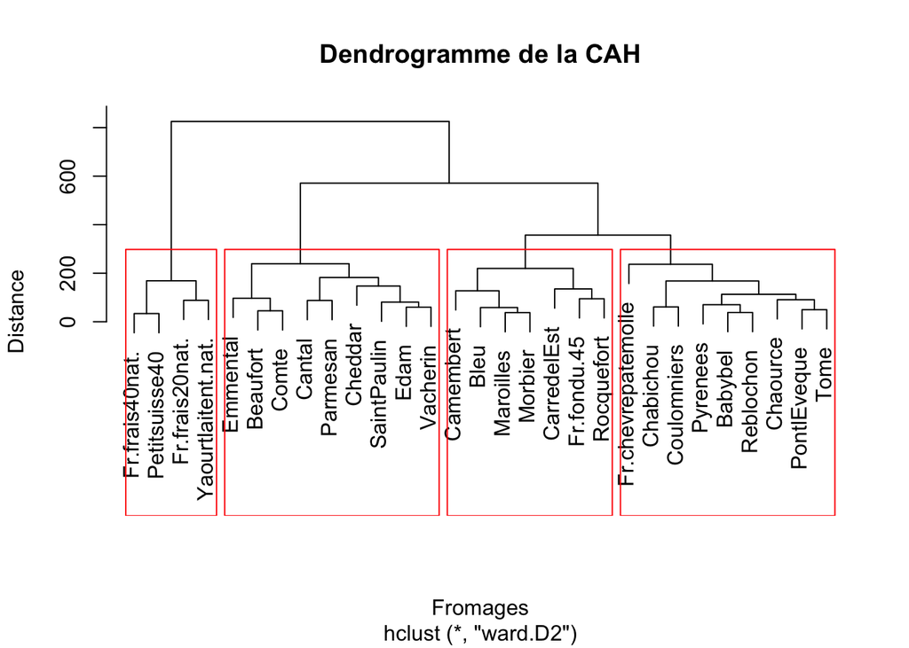

# Analyse des groupes

Comme vu précédemment on a bien un groupe de fromages frais industriels.  
Ensuite nous avons un groupe de fromage que l’on peut définir comme fort avec entre autre le `Camembert`, `bleu` ou encore le `Maroilles`.  
Pour les deux derniers groupes la différences est moins évidentes, surement que des connaisseurs pourront mieux les différencier. Peut être une différence entre pâte dur et pâte molle.

# De même avec le critère d’aggrégation du lien simple

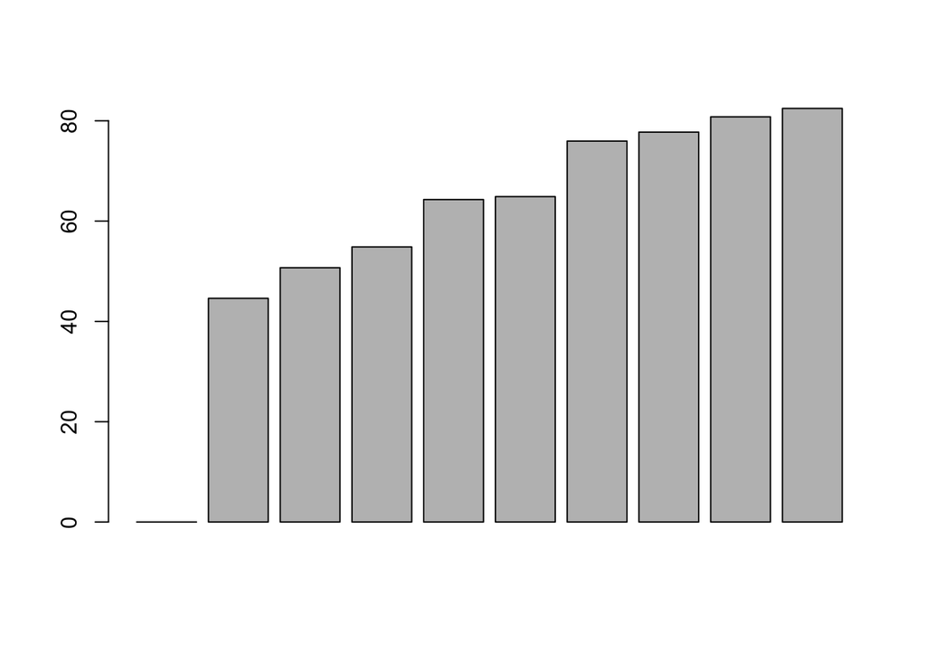

En utilisant le critère du coude on retient 2 classes.

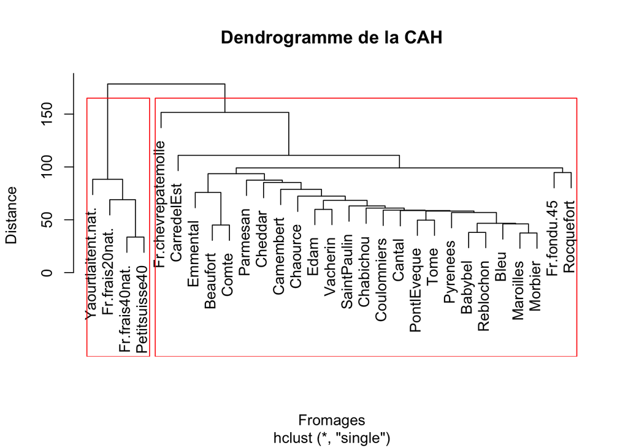

Nous avons donc un groupe de fromages frais industriels et un groupe de ‘vrais’ fromages.